# Project_3_Focal_Stats

## **QGIS Exploritory Analysis:**

[figure not shown]

Small scale first looks into my damage polygons and my trees per acre raster.

## **Old Hypothesis:**

Tree pest infestation (focus on Douglas-fir Beetle) related tree mortality is spatially clustered around areas with higher trees per acre (over 100).

```python
import pandas as pd
import osmnx
import geopandas as gpd
import rioxarray
import xarray
import datashader
import contextily as cx
from shapely import geometry
import matplotlib.pyplot as plt
import os
import numpy as np
import dask.array as da
```

```python
#read raster
tpa = "Data/R1_Douglasfir_TPA.tif"
```

```python
#asign damage breaks to unique variables
very_light = gpd.read_file("Data/Damage_breaks_douglasfir_beetle.gpkg", layer='Very Light (1-3%)')
light = gpd.read_file("Data/Damage_breaks_douglasfir_beetle.gpkg", layer='Light (4-10%)')
moderate = gpd.read_file("Data/Damage_breaks_douglasfir_beetle.gpkg", layer='Moderate (11-29%)')
severe = gpd.read_file("Data/Damage_breaks_douglasfir_beetle.gpkg", layer='Severe (30-50%)')
very_severe = gpd.read_file("Data/Damage_breaks_douglasfir_beetle.gpkg", layer='Very Severe (>50%)')
```

```python
#mask negative or absent values from raster
raster = rioxarray.open_rasterio(tpa, chunks={"x": 1024, "y": 1024})

masked_raster = raster.where((raster >= 0) & (raster < 1667)) #masks negatives and extremes (above 1666 based on treemap website)

masked_raster.rio.to_raster("Data/masked_tpa(updated).tif")
```

```python
#New masked raster
tpa = "Data/masked_tpa(updated).tif"
```

```python
#zonal stats for very_light damage class
from rasterstats import zonal_stats
very_light_stats = zonal_stats(
    vectors=very_light,
    raster=tpa,
    stats=["mean", "median", "max", "min", "std", "majority", "minority","sum"],
    nodata=0,
    all_touched=True
)

#append zonal stats back onto polygons
stats_df = pd.DataFrame(very_light_stats)

very_light = very_light.reset_index(drop=True)

very_light_with_stats = pd.concat([very_light, stats_df], axis=1)
```

```python
#zonal stats for light damage class
from rasterstats import zonal_stats
light_stats = zonal_stats(
    vectors=light,
    raster=tpa,
    stats=["mean", "median", "max", "min", "std", "majority", "minority","sum"],
    nodata=0,
    all_touched=True
)

#append zonal stats back onto polygons
stats_df1 = pd.DataFrame(light_stats)

light = light.reset_index(drop=True)

light_with_stats = pd.concat([light, stats_df1], axis=1)
```

```python
#zonal stats for moderate damage class
from rasterstats import zonal_stats
moderate_stats = zonal_stats(
    vectors=moderate,
    raster=tpa,
    stats=["mean", "median", "max", "min", "std", "majority", "minority","sum"],
    nodata=0,
    all_touched=True
)

#append zonal stats back onto polygons
stats_df2 = pd.DataFrame(moderate_stats)

moderate = moderate.reset_index(drop=True)

moderate_with_stats = pd.concat([moderate, stats_df2], axis=1)
```

```python
#zonal stats for severe damage class
from rasterstats import zonal_stats
severe_stats = zonal_stats(
    vectors=severe,
    raster=tpa,
    stats=["mean", "median", "max", "min", "std", "majority", "minority","sum"],
    nodata=0,
    all_touched=True
)

#append zonal stats back onto polygons
stats_df3 = pd.DataFrame(severe_stats)

severe = severe.reset_index(drop=True)

severe_with_stats = pd.concat([severe, stats_df3], axis=1)
```

```python
#zonal stats for very_severe damage class
from rasterstats import zonal_stats
very_severe_stats = zonal_stats(
    vectors=very_severe,
    raster=tpa,
    stats=["mean", "median", "max", "min", "std", "majority", "minority","sum"],
    nodata=0,
    all_touched=True
)

#append zonal stats back onto polygons
stats_df4 = pd.DataFrame(very_severe_stats)

very_severe = very_severe.reset_index(drop=True)

very_severe_with_stats = pd.concat([very_severe, stats_df4], axis=1)
```

```python
#stats to plot
stats_to_plot = ['majority', 'mean']
```

### **Results of Zonal Stats:**

The purposes of this notebook was to address my original hypothesis that aimed to determine whether trees per acre amounts were higher in pixels that were within high Douglas-fir beetle damage polygons (i.e. moderate-very severe damage classes). The histograms below aimed to gauge whether my hypothesis was true, but in actually, the results were different than I expected. The mean pixel value, representing trees per acre in 30 meter resolution, did not differ between damage type polygons as I had hypothesized, and in fact was mostly unifrom. Based on this, I needed to pivot to a new hypothesis that gauged spatial clustering of only the polygons. The aim with the trees per acre raster was now to run zonal stats on calculated significant polygons in the four LISA catagories, post Moran's I.

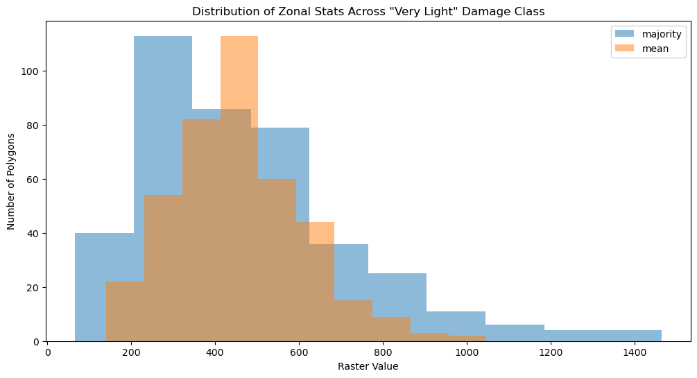

```python
plt.figure(figsize=(12, 6))
for stat in stats_to_plot:
    plt.hist(very_light_with_stats[stat], bins=10, alpha=0.5, label=stat)  # alpha=transparency
plt.title('Distribution of Zonal Stats Across "Very Light" Damage Class')
plt.xlabel('Raster Value')
plt.ylabel('Number of Polygons')
plt.legend()
plt.show()
```

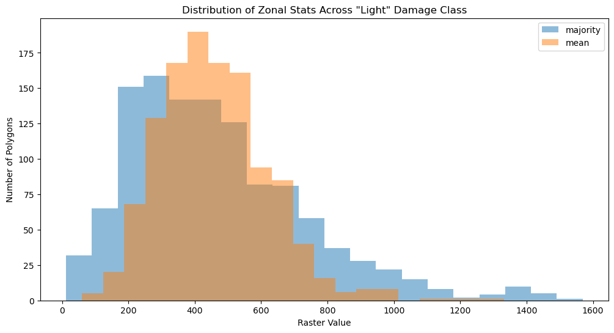

```python
plt.figure(figsize=(12, 6))
for stat in stats_to_plot:
    plt.hist(light_with_stats[stat], bins=20, alpha=0.5, label=stat)  # alpha=transparency
plt.title('Distribution of Zonal Stats Across "Light" Damage Class')
plt.xlabel('Raster Value')
plt.ylabel('Number of Polygons')
plt.legend()
plt.show()
```

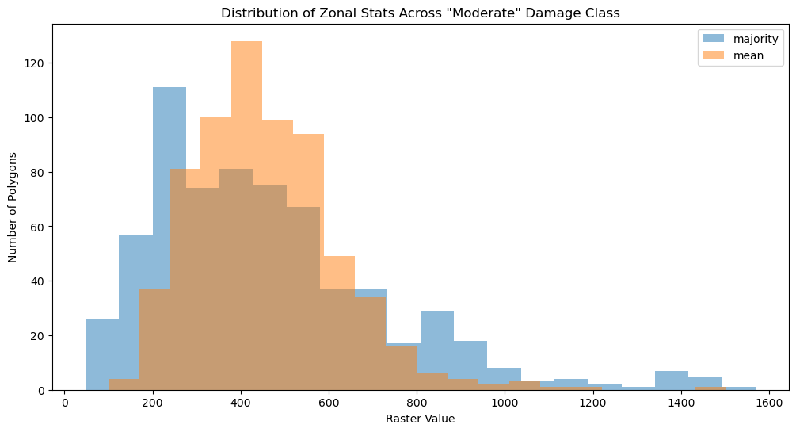

```python
plt.figure(figsize=(12, 6))
for stat in stats_to_plot:
    plt.hist(moderate_with_stats[stat], bins=20, alpha=0.5, label=stat)  # alpha=transparency
plt.title('Distribution of Zonal Stats Across "Moderate" Damage Class')
plt.xlabel('Raster Value')
plt.ylabel('Number of Polygons')
plt.legend()
plt.show()
```

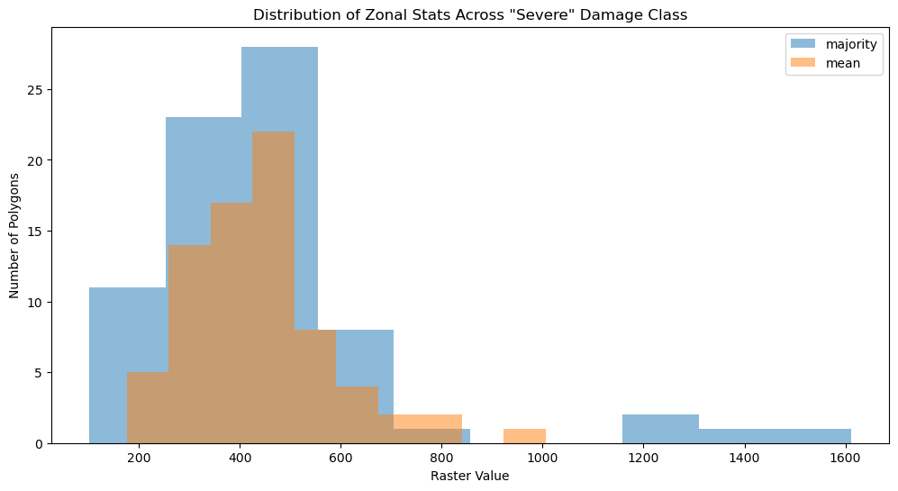

```python
plt.figure(figsize=(12, 6))
for stat in stats_to_plot:
    plt.hist(severe_with_stats[stat], bins=10, alpha=0.5, label=stat)  # alpha=transparency
plt.title('Distribution of Zonal Stats Across "Severe" Damage Class')
plt.xlabel('Raster Value')
plt.ylabel('Number of Polygons')
plt.legend()
plt.show()
```

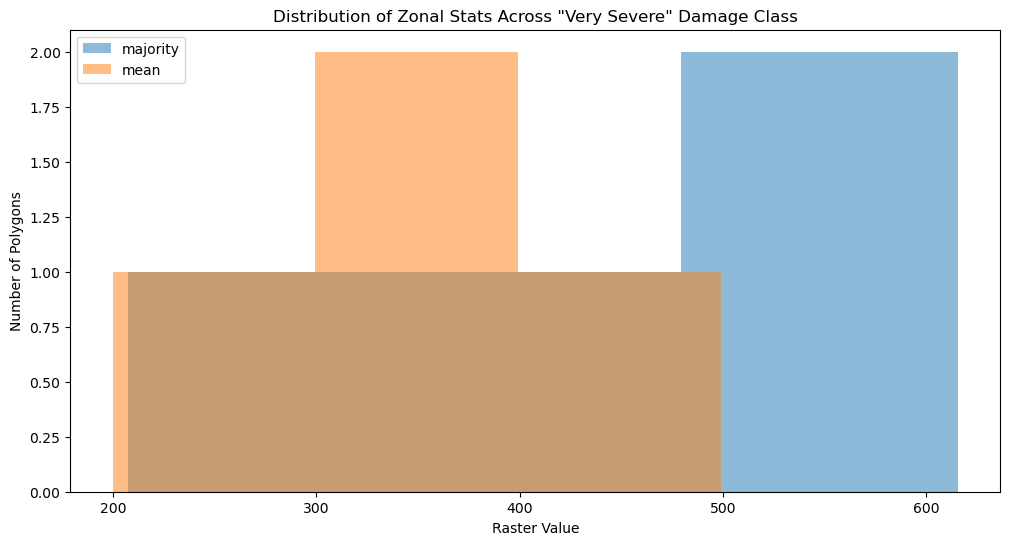

```python
plt.figure(figsize=(12, 6))
for stat in stats_to_plot:
    plt.hist(very_severe_with_stats[stat], bins=3, alpha=0.5, label=stat)  # alpha=transparency
plt.title('Distribution of Zonal Stats Across "Very Severe" Damage Class')
plt.xlabel('Raster Value')
plt.ylabel('Number of Polygons')
plt.legend()
plt.show()
```